# Estudio ofertas laborales Tarapacá

# Resumen general

El presente reporte es un estudio de 1.873 publicaciones laborales de la región de Tarapacá, empleos publicados entre abril 2021 y diciembre 2021. Entre la información rescatada esta la empresa, categoría del empleo, tipo de cargo, comuna, jornada laboral y requisitos.

## Indice

Se realiza un estudio general de las categoría de los empleos (informaciones generales), ademas, de un estudio de los requisitos por las 8 principales categorías de empleos.

- Informaciones generales
- Construcción/Industrial/Automotriz
- Comercio/Ventas
- Minería
- Tecnología
- Financiera
- Química y salud
- Alimentos
- Administración

[interactive chart not shown]

# Informaciones generales

Los trabajos se dividen en 8 grandes categorías

- Construcción/Industrial/Automotriz: 395 ofertas
- Comercio/Ventas: 392 ofertas
- Minería: 335 ofertas
- Tecnología: 262 ofertas
- Financiera: 202 ofertas
- Química y salud: 136 ofertas
- Alimentos: 100 ofertas
- Administración: 51 ofertas

En cuanto a los requisitos de estudios, el 21.4% solicita nivel universitario, 20.4% técnico nivel superior y 11.3% técnico nivel medio. El 42.4% no informa sobre los niveles de estudios requeridos para el empleo.

Respecto al tipo de jornada laboral, un 4.5% de las ofertas señalan una modalidad de teletrabajo y un 2.9% modalidad mixta.

- Jornada Completa: 54.6%
- Por Turnos: 20.8%
- En Terreno: 9.2%
- Teletrabajo: 4.5%
- Part Time: 4.2%
- Mixta (teletrabajo + Presencial): 2.9%
- No informa: 1.1%
- Media Jornada: 0.9%
- Práctica: 0.6%
- Reemplazo: 0.6%
- Comisionista: 0.5%

## Estudio requisitos

Por medio de cadenas de Markov, se puede estudiar los prinicpales requisitos en terminos generales de los empleos son:

- Estudios técnicos
- Carrera afín
- Office nivel medio/avanzado
- Experiencia en cargos similares
- Licencia de conducción clase b y d
- Ingeniero civil industrial
- Turnos rotativos 14x14
- Salud compatible con el cargo
- Disponibilidad inmediata
- Disponibilidad para trabajos a gran altura geográfica
- Experiencia con maquinas pesada
- Enseñanza media completa
- Visa definitiva para extranjeros

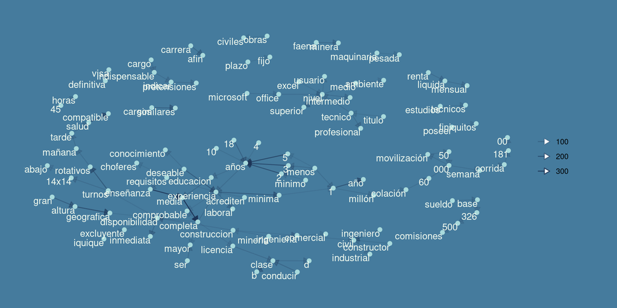

# Construcción/Industrial/Automotriz

El siguiente apartado es un estudio de los empleos de las categorías construcción/industrial y automotriz. Las sub-categorias de empleos son:

- Construcción
- Maquinaria y Equipo
- Automotriz
- Energía / Electricidad / Electrónica
- Industrial
- Agua / Obras Sanitarias
- Combustibles (Gas / Petróleo)
- Cemento y Materiales
- Petroleo / Gas / Combustibles

Donde las jornadas laborales son principalmente por turno y completa

- Jornada Completa: 49.9%
- Por Turnos: 40.3%
- En Terreno: 6.1%
- No informa: 2.3%
- Teletrabajo: 0.8%
- Práctica: 0.5%
- Mixta (teletrabajo + Presencial): 0.3%

Requisitos de estudios

- No informa 28.9%
- Técnico profesional superior 27.3%
- Universitaria 27.1%
- Técnico medio/ colegio técnico 8.6%
- Básica 7.6%
- Postgrado 0.5%

## Estudio de requisitos

- Residencia en Iquique
- Enseñanza media completa
- Ingeniero civil
- Licencia de conducir clase b
- Disponibilidad de turnos 14x14
- Office nivel superior
- Estudios técnico profesional
- Habilidad con herramientas computacionales

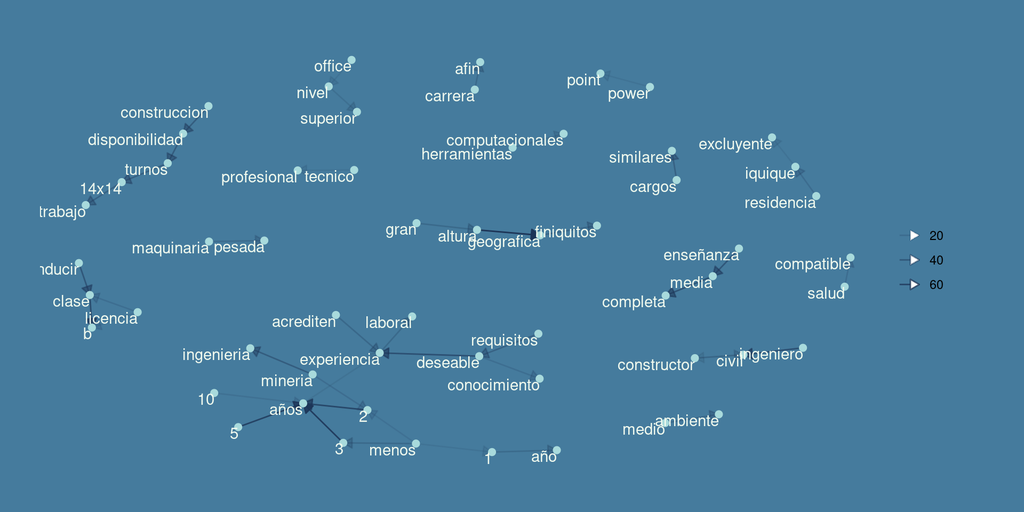

# Comercio/Ventas

El siguiente apartado es un estudio de los empleos de las categorías Comercio y Ventas. Las sub-categorias de empleos son:

- Retail
- Comercial
- Ventas
- Grandes Tiendas
- Consumo masivo
- Hipermercados

- Jornada Completa 69.6%
- Part Time 13.8%
- Por Turnos 6.1%
- Media Jornada 3.6%
- Teletrabajo 2.3%
- En Terreno 1.5%
- Mixta (teletrabajo + Presencial) 1.5%
- Comisionista 0.8%
- Práctica 0.5%

Requisitos de estudios

- No informa 60.5%
- Técnico profesional superior 14.3%
- Técnico medio/ colegio técnico 13.5%
- Universitaria 7.1%
- Básica 4.6%

## Estudio de requisitos

- Excel nivel intermedio
- Disponibilidad inmediata
- Experiencia en cargos similares
- Estudios técnicos profesionales
- Enseñanza media completa

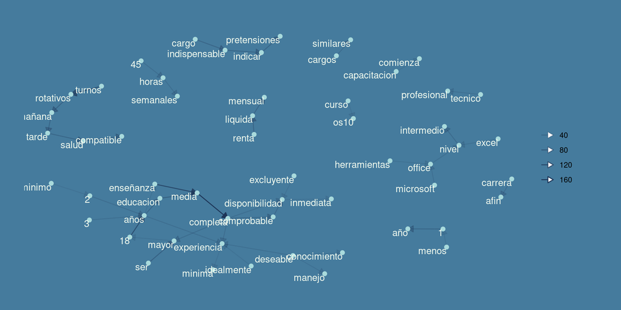

# Minería

El siguiente apartado es un estudio de los empleos de del rubro de la minería. Las jornadas de los empleos del rubro de la minería son:

- Jornada Completa 32.5%
- En Terreno 30.7%
- Por Turnos 28.1%
- No informa 2.4%
- Teletrabajo 2.1%
- Práctica 1.8%
- Reemplazo 1.5%
- Mixta (teletrabajo + Presencial) 0.9%

Requisitos de estudios

- No informa 40.3%
- Universitaria 27.2%
- Técnico medio/ colegio técnico 15.5%
- Técnico profesional superior 13.4%
- Básica 3%
- Postgrado 0.6%

## Estudio de requisitos

- Salud compatible con gran altitud geográfica
- Visa definitiva para extranjeros
- Experiencia en cargos similares
- Turnos rotativos 14x14
- Enseñanza media completa
- Licencia de conducir clase b y d
- Experiencia como operador
- Disponibilidad para trabajar en faena minera
- Experiencia con operación de grúas horquilla
- Ingeniería civil

[figure not shown]

# Tecnología

El siguiente apartado es un estudio de los empleos de del rubro de la tecnología Las jornadas de los empleos del rubro son:

- Jornada Completa 38.5%
- Teletrabajo 18.3%
- Por Turnos 17.9%
- En Terreno 13.4%
- Mixta (teletrabajo + Presencial) 7.3%

Requisitos de estudios

- No informa 35.5%
- Universitaria 27.9%
- Técnico profesional superior 18.3%
- Técnico medio/ colegio técnico 13.7%
- Básica 4.6%

## Estudio de requisitos

- Enseñanza media completa
- Contrato bajo articulo 22
- Experiencias especificas del rubro
- Disponibilidad inmediata
- Visa definitiva
- Estudios técnicos medio
- Trabajo en gran altura geográfica

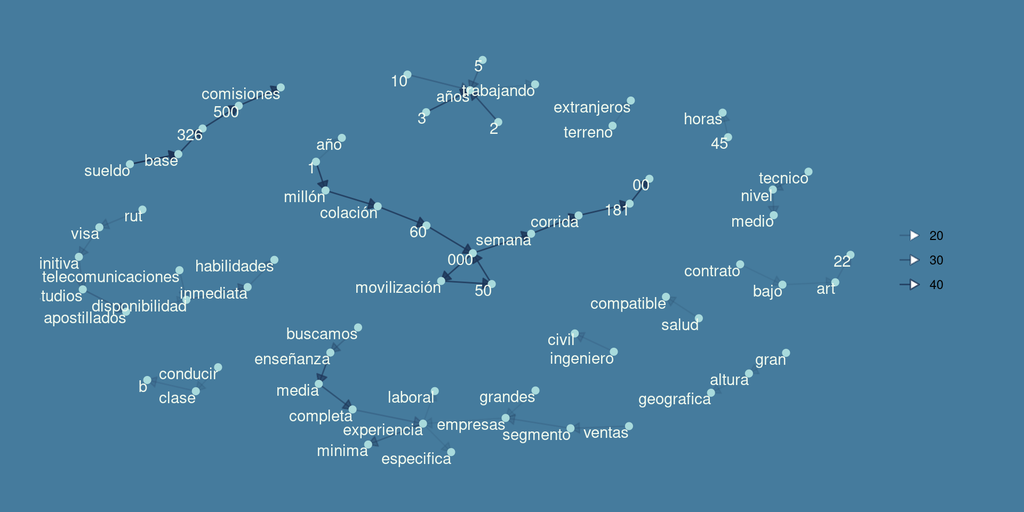

# Financiera

Empleos del rubro de las finanzas. Las sub-categorías englobadas son:

- Seguros / Previsión
- Banca / Financiera
- Inmobiliaria/Propiedades
- Servicios Financieros Varios
- Inversiones (Soc / Cías / Holding)

Los trabajos de este indole son principalmente de jornada completa

- Jornada Completa 78.7%
- Mixta (teletrabajo + Presencial) 10.9%
- Teletrabajo 6.4%
- Por Turnos 2%
- Part Time 1%
- Media Jornada 0.5%
- No informa 0.5%

## Estudio de requisitos

- Estudios técnicos
- Experiencia en rubro financiero/bancario
- Enseñanza media completa
- Conocimientos sobre seguros
- Ingeniería comercial

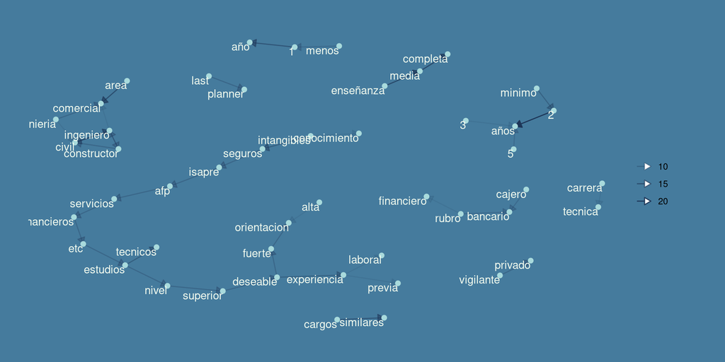

# Química y salud

Los empleos del área de la química y salud tienen principalmente jornadas de tiempo completo (78.7%) y por turnos (14.7%). En cuanto a los estudios requeridos estos son técnicos superior en un 40% de las ofertas y universitaria en el 36% de los casos

## Estudio de requisitos

- Experiencia laboral en el área de la salud
- Titulo técnico nivel superior/ Estudios universitarios
- Registro SIS
- Manejo básico de rayos
- Disponibilidad inmediata

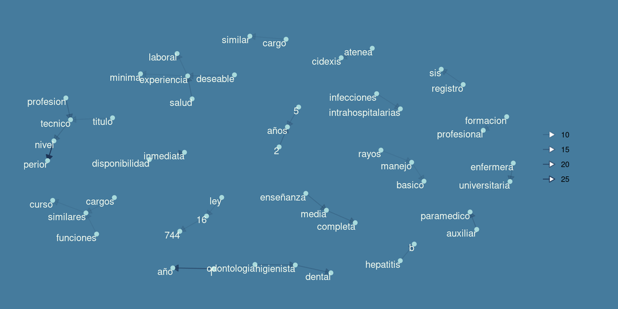

# Alimentos

Se dispone de información de 100 empleos relacionados con los alimentos, principalmente despacho de estos. En estos trabajos, el 42% ofrece trabajo por turnos y un 40% jornada completa, además, el 18% solicita estudios nivel técnicos medio y un 17% técnico superior.

## Estudio de requisitos

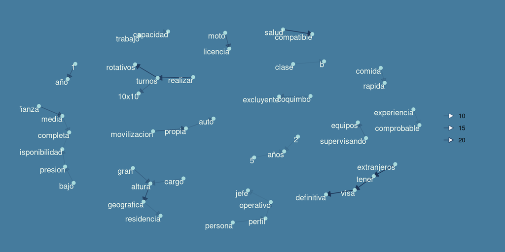

# Administración

Los trabajos de carácter administrativo que se ofrecen son principalmente en organizaciones sin fines de lucro, recuersos humanos y consultoria. Estos trabajos son principalmente de jornada completa (72%), además, un 47% de las ofertas solicitan estudios universitarios.

## Estudio de requisitos

- Disponibilidad inmediata
- Habilidades con relaciones interpersonales
- Office nivel medio
- Experiencia con cargos similares
- Enseñanza media completa

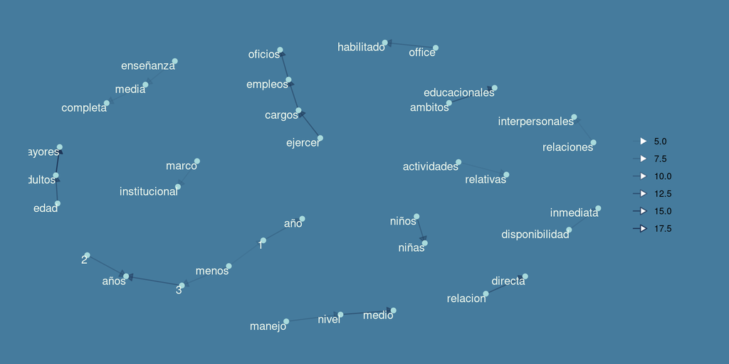